**Google PageRank**

By Prof. Seungchul Lee  
http://iai.postech.ac.kr/  
Industrial AI Lab at POSTECH

Table of Contents

# 1. Degree and Importance of Network

## 1.1. Degree

**Degree of Undirected Graph**

- The degree of vertex in a graph is the number of edges connected to it
- denote the degree of vertex $i$ by $k_{i}$
- for an undirected graph of $n$ vetices

$$ k_i = \sum_{j=1}^{n} \; A_{ij} $$

- Every edge in an undirected graph has two ends and if there are $m$ edges

$$ 2m = \sum_{i=1}^{n} \; k_i $$

- the mean degree $c$ of a vertex

$$ c = \frac{1}{n} \sum_{i=1}^{n} \; k_i $$

- the maximum possible number of edges in a graph is $\left( \begin{array}{c} n\\2 \end{array} \right) = \frac{n(n-1)}{2}$
- *density* $\rho$ of a graph is the fraction of these edges that are actually present

$$ \rho = \frac{m}{\left( \begin{array}{c} n\\2 \end{array} \right)}$$

**Degree of Directed Graph**

- in-degree: the number of incoming edges connected to a vertex

$$ k_i^{\text{in}} = \sum_{j=1}^{n} \; A_{ij} $$

- out-degree: the number of outgoing edges

$$ k_i^{\text{out}} = \sum_{i=1}^{n} \; A_{ij} $$

## 1.2. Centrality

- Which are the most *important* or central vertices in a network?
- *degree centrality* is a simple centrality measure
  - in a social network, it seems reasonable to suppose that inidividuals who have connections to many others might have more influence, more access to information

**Eigenvector centrality**

- not all neighbors are equivalent
- increase importance by having connections to other vertices that are *themselves important*
- sum of the centrality (ranks, scores) of its in-comming neighbors
- iteratively update

$$ \begin{align*} r_i \leftarrow \sum_{j \, \in \, N(i)} r_j = \sum_{j} A_{ji}r_j \end{align*} $$

- matrix form with a *row* vector of $r$

$$ \begin{align*} &1) \quad r \leftarrow r\,A &\text{update}\\ &2) \quad r \leftarrow \frac{r}{\parallel r \parallel_1}& \text{normalize} \end{align*} $$

- left eigenvector of the adjacency matrix A associated with the largest eigenvalue

$$ \lambda \, r = r\,A $$

- [online note](http://www.sci.unich.it/~francesc/teaching/network/eigenvector.html)

# 2. Google PageRank

- Source
  - Networks: Friends, Money, and Bytes
  - by Prof. Mung Chiang at Princeton University
  - [youtube](https://www.youtube.com/user/Network20Q/playlists) playlist
- Consider World Wide Web as a graph (or network)
- Question: which page is more important?
- For Google, which page among google search results should be placed on top?

[figure not shown]

- Read [Wikipedia](https://en.wikipedia.org/wiki/PageRank)
- The [original PageRank paper](http://infolab.stanford.edu/~backrub/google.html) by Google’s founders Sergey Brin and Lawrence Page

## 2.1. PageRank

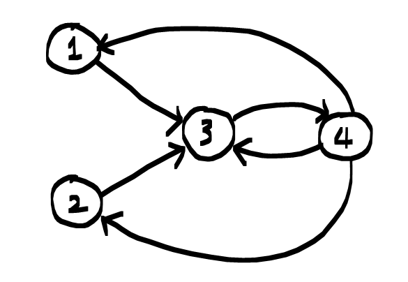

$$ A = \begin{bmatrix} 0 & 0 & 1 & 0\\ 0 & 0 & 1 & 0\\ 0 & 0 & 0 & 1\\ 1 & 1 & 1 & 0 \end{bmatrix}$$

- In-degree
  - What makes a page important?
  - Possible measure
    - In-degree: measure of the number of incoming links a node has ($1,1,3,1$)
  - Does this tell the whole story?
- Important score

$$ \pi = \left[\pi_1,\, \pi_2,\, \pi_3,\, \pi_4 \right]$$

- Importance score, $\pi_i$ for node $i$
  - each node...
  - has its own importance score
  - Spreads an equal amount of its importance to each outgoing link
- *row vector by convention*
- Out-degree: the number of outgoing links from a node $\to (1,1,1,3)$
- *Markov chain* with transition probability matrix $H$

$$ H = D^{-1}A = \begin{bmatrix} 1 & 0 & 0 & 0\\ 0 & 1 & 0 & 0\\ 0 & 0 & 1 & 0\\ 0 & 0 & 0 & \frac{1}{3} \end{bmatrix} \begin{bmatrix} 0 & 0 & 1 & 0\\ 0 & 0 & 1 & 0\\ 0 & 0 & 0 & 1\\ 1 & 1 & 1 & 0 \end{bmatrix} = \begin{bmatrix} 0 & 0 & \frac{1}{1} & 0\\ 0 & 0 & \frac{1}{1} & 0\\ 0 & 0 & 0 & \frac{1}{1}\\ \frac{1}{3} & \frac{1}{3} & \frac{1}{3} & 0 \end{bmatrix}$$

- Simultaneous equations
  - We can write each node's score in terms of its incoming links
  - Recursion: seemingly circular logic

$$ \begin{align*} \pi_1 &= \frac{\pi_4}{3}\\ \pi_2 &= \frac{\pi_4}{3}\\ \pi_3 &= \pi_1 + \pi_2 + \frac{\pi_4}{3}\\ \pi_4 &= \pi_3 \end{align*} $$

$$ H = \begin{bmatrix} 0 & 0 & \frac{1}{1} & 0\\ 0 & 0 & \frac{1}{1} & 0\\ 0 & 0 & 0 & \frac{1}{1}\\ \frac{1}{3} & \frac{1}{3} & \frac{1}{3} & 0 \end{bmatrix}$$

- or eigenvalue problem (transposed)

$$ \left[\pi_1,\, \pi_2,\, \pi_3,\, \pi_4 \right] \times \begin{bmatrix} 0 & 0 & \frac{1}{1} & 0\\ 0 & 0 & \frac{1}{1} & 0\\ 0 & 0 & 0 & \frac{1}{1}\\ \frac{1}{3} & \frac{1}{3} & \frac{1}{3} & 0 \end{bmatrix} = 1\left[\pi_1,\, \pi_2,\, \pi_3,\, \pi_4 \right] $$

```python
import numpy as np
import matplotlib.pyplot as plt
%matplotlib inline
```

```python
A = np.matrix([[0, 0, 1, 0],
              [0, 0, 1, 0],
              [0, 0, 0, 1],
              [1, 1, 1, 0]])

d = np.diag([1, 1, 1, 3])
d = np.asmatrix(d)

H = d.I*A
```

```python
# eigenvalue

[D, V] = np.linalg.eig(H.T)

print(D) # check one of eigenvalue = 1
print(V[:,0]/np.sum(V[:,0]))
```

```
[ 1.0000000e+00+0.j         -5.0000000e-01+0.64549722j
 -5.0000000e-01-0.64549722j  6.2307862e-35+0.j        ]
[[0.125-0.j]
 [0.125-0.j]
 [0.375-0.j]
 [0.375-0.j]]
```

```python
# iterative

# random initialization
r = np.random.rand(1,4)
r = r/np.sum(r)
print(r)
```

```
[[0.30686635 0.39529553 0.10359321 0.1942449 ]]
```

```python
for _ in range(100):
    r = r*H

print(r)
```

```
[[0.125 0.125 0.375 0.375]]
```

```python
r = np.random.rand(1,4)
r = r/np.sum(r)

r_pre = 1/4*np.ones([1,4])

while np.linalg.norm(r_pre - r) > 1e-10:
    r_pre = r
    r = r*H

print(r)
```

```
[[0.125 0.125 0.375 0.375]]
```

- Dangling nodes
  - Does what we just presented always lead to a unique solution?
  - Not quite yet !

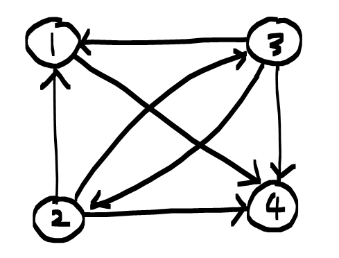

  - Dangling nodes
    - nodes that do not point to any others
    - lead to no meaningful solution
    - Solution: assume dangling node points to every node in the graph ($\rightarrow$ random surfer)
- The Random Surfer
  - Surfing the web at random
  - Two possible actions
    - pick a hyperlink randomly from the current page
    - enter a URL randomly
  - Stochastic matrix $H'$

$$H' = H + \frac{1}{N}d \mathbf{1}^T \qquad$$

$\qquad \qquad $where $d$ is dangling (absorbing) nodes indicator column vector and $\mathbb{1}$ is a unit column vector

$$ H' = \begin{bmatrix} 0 & 0 & 0 & 1\\ \frac{1}{3} & 0 & \frac{1}{3} & \frac{1}{3}\\ \frac{1}{3} & \frac{1}{3} & 0 & \frac{1}{3}\\ 0 & 0 & 0 & 0 \end{bmatrix} + \begin{bmatrix} 0 & 0 & 0 & 0\\ 0 & 0 & 0 & 0\\ 0 & 0 & 0 & 0\\ \frac{1}{4} & \frac{1}{4} & \frac{1}{4} & \frac{1}{4} \end{bmatrix} = H + \frac{1}{4} \begin{bmatrix} 0\\0\\0\\1\end{bmatrix} \begin{bmatrix} 1 & 1 & 1 &1 \end{bmatrix} $$

```python
A = np.matrix([[0, 0, 0, 1],
               [1, 0, 1, 1],
               [1, 1, 0, 1],
               [0, 0, 0, 0]])

s = np.sum(A, axis = 1)

H2 = np.zeros(A.shape)

for i in range(4):
    if s[i,0] != 0:
        H2[i,:] = A[i,:]/s[i,0]
    else:
        H2[i,:] = 1/4*np.ones([1,4])

H2 = np.asmatrix(H2)
print(H2)
```

```
[[0.         0.         0.         1.        ]
 [0.33333333 0.         0.33333333 0.33333333]
 [0.33333333 0.33333333 0.         0.33333333]
 [0.25       0.25       0.25       0.25      ]]
```

```python
r = np.random.rand(1,4)
r = r/np.sum(r)

r_pre = 1/4*np.ones([1,4])

while np.linalg.norm(r_pre - r) > 1e-10:
    r_pre = r
    r = r*H2

print(r)
```

```
[[0.22222222 0.16666667 0.16666667 0.44444444]]
```

- Disconnected graph
  - Connected component - group of nodes which can reach eath other, but none outside of the group
  - More than one connected component
    - Infinitely many solutions
    - Stuck in subgraph forever
    - Solution: add the purely random surfing into the mix
      - you get bored, enter a URL randomly
  - PageRank: what is the chance a page is selected at any time?
  - Google matrix $G$

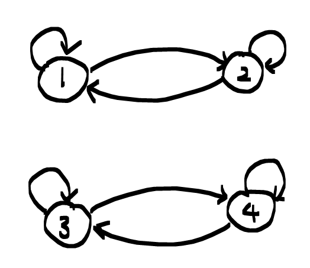

$$ G = \alpha \begin{bmatrix} \frac{1}{2} & \frac{1}{2} & 0 & 0\\ \frac{1}{2} & \frac{1}{2} & 0 & 0\\ 0 & 0 & \frac{1}{2} & \frac{1}{2}\\ 0 & 0 & \frac{1}{2} & \frac{1}{2} \end{bmatrix} + (1-\alpha) \frac{1}{4}\begin{bmatrix} 1 & 1 & 1 & 1\\ 1 & 1 & 1 & 1\\ 1 & 1 & 1 & 1\\ 1 & 1 & 1 & 1 \end{bmatrix} $$

$$G = \alpha H' + (1-\alpha)\frac{1}{N}\mathbf{1}\mathbf{1}^T$$

```python
A = np.matrix([[1, 1, 0, 0],
               [1, 1, 0, 0],
               [0, 0, 1, 1],
               [0, 0, 1, 1]])

s = np.sum(A, axis = 1)

H2 = np.zeros(A.shape)

for i in range(4):
    if s[i,0] != 0:
        H2[i,:] = A[i,:]/s[i,0]
    else:
        H2[i,:] = 1/4*np.ones([1,4])

H2 = np.asmatrix(H2)
print(H2, '\n')

alpha = 0.85;
G = alpha*H2 + (1-alpha)*1/4*np.ones([4,4])
G = np.asmatrix(G)

print(G)
```

```
[[0.5 0.5 0.  0. ]
 [0.5 0.5 0.  0. ]
 [0.  0.  0.5 0.5]
 [0.  0.  0.5 0.5]]

[[0.4625 0.4625 0.0375 0.0375]
 [0.4625 0.4625 0.0375 0.0375]
 [0.0375 0.0375 0.4625 0.4625]
 [0.0375 0.0375 0.4625 0.4625]]
```

```python
r = np.random.rand(1,4)
r = r/np.sum(r)

r_pre = 1/4*np.ones([1,4])

while np.linalg.norm(r_pre - r) > 1e-10:
    r_pre = r
    r = r*G

print(r)
```

```
[[0.25 0.25 0.25 0.25]]
```

## 2.2. PageRank Computations

1. Eigenvalue problem (choose left eigenvector $\pi$ with $\lambda = 1$)

   $$ \pi G = 1 \pi \implies \pi = \alpha \pi H' + (1-\alpha)\frac{1}{N}\mathbf{1}^T$$

   where $\pi$ is stationary distribution of Markov chain, and raw vector by convention
2. Power iterations:

$$ \pi \leftarrow \pi \left(\alpha H' + (1-\alpha)\frac{1}{N}\mathbf{1}\mathbf{1}^T \right) = \alpha \pi H' + (1-\alpha)\frac{1}{N}\mathbf{1}^T $$

## 2.3. Summary

$$ \begin{align*} H & &\text{from webgraph}\\ H'& = H + \frac{1}{N}d \mathbf{1}^T &\text{to overcome dangling issue}\\ G &= \alpha H' + (1-\alpha)\frac{1}{N}\mathbf{1}\mathbf{1}^T= \alpha \left( H + \frac{1}{N}d \mathbf{1}^T\right) + (1-\alpha)\frac{1}{N}\mathbf{1}\mathbf{1}^T &\text{to overcome disconnected subgraph} \end{align*} $$

$$ \pi [k+1] = \pi [k] G$$

```python
%%javascript
$.getScript('https://kmahelona.github.io/ipython_notebook_goodies/ipython_notebook_toc.js')
```